# 20210601/0630_SS2_ZY, final

ILC2 IL25+/-, in vitro (02/)04/48/72h  
(02h invitro ILC2 not stable, not involved in merged downstream analysis)

```r
getwd()
```

```
## [1] "J:/projects_local/projects/20210630_SS2_ZY/final_0811"
```

## comparison of DEGs

### cutoffs to overlap

##### TPM > 10 in at least 3 cells of one condition

```r
#
cut_tpm <- 10
cut_cell <- 3

#
matt_pc.cut <- matt_pc
matt_pc.cut <- matt_pc.cut[rowSums(matt_pc.cut[,idx.nonIL25_C04h] > cut_tpm) >= cut_cell |
                           rowSums(matt_pc.cut[,idx.nonIL25_C48h] > cut_tpm) >= cut_cell |
                           rowSums(matt_pc.cut[,idx.nonIL25_C72h] > cut_tpm) >= cut_cell |
                           rowSums(matt_pc.cut[,idx.IL25_C04h] > cut_tpm) >= cut_cell |
                           rowSums(matt_pc.cut[,idx.IL25_C48h] > cut_tpm) >= cut_cell |
                           rowSums(matt_pc.cut[,idx.IL25_C72h] > cut_tpm) >= cut_cell,]
```

```r
dim(matt_pc.cut[,-c(idx.IL25_C02h,idx.nonIL25_C02h)])
```

```
## [1] 7256   24
```

```r
head(matt_pc.cut[,-c(idx.IL25_C02h,idx.nonIL25_C02h)])
```

```
##                C04h1  C04h2  C04h3  C04h4  C04h5  C04h6  C04h7  C04h8  C48h1
## 0610009B22Rik  21.26  24.08  24.88  20.31  14.88  16.94  21.17  10.63  41.41
## 0610010K14Rik  51.61  66.46  67.06  61.19  58.70  68.08  66.62  55.93 104.24
## 0610012G03Rik  45.28  40.28  33.81  44.32  36.24  32.39  34.34  33.24  74.02
## 0610030E20Rik  26.32  21.54  20.28  22.55  25.56  19.27  19.53  22.83  15.62
## 1110004F10Rik 185.40 186.65 183.46 166.27 210.16 181.72 230.08 200.48 153.41
## 1110008P14Rik  70.06  58.54  61.96  82.13  45.21  47.63  49.26  63.01  81.81
##                C48h2  C48h3  C48h4  C48h5  C48h6  C48h7  C48h8  C72h1  C72h2
## 0610009B22Rik  31.91  41.36  36.33  33.20  32.68  37.04  32.29  33.17  44.37
## 0610010K14Rik 113.16  90.76  93.41  75.29  83.29  86.47  76.81  76.53  90.27
## 0610012G03Rik  67.13  60.04  63.21  48.69  59.05  59.43  49.57  70.56  83.64
## 0610030E20Rik  20.53  20.98  21.39  10.88  10.61  11.35  10.58  18.00  23.29
## 1110004F10Rik 174.91 182.70 162.32 215.47 190.62 200.56 202.03 190.18 133.40
## 1110008P14Rik  84.27  85.90  92.80  57.48  78.64  83.90  73.01  83.45  88.45
##                C72h3  C72h4  C72h5  C72h6  C72h7  C72h8
## 0610009B22Rik  39.30  35.51  25.00  31.87  32.94  29.36
## 0610010K14Rik  90.21  80.46  47.72  74.76  66.51  63.84
## 0610012G03Rik  66.06  62.72  76.64  61.32  62.50  67.08
## 0610030E20Rik  19.15  24.96  11.92  12.06  12.79   9.80
## 1110004F10Rik 161.01 167.61 119.38 139.87 164.46 143.55
## 1110008P14Rik  87.57  81.69  97.16 108.28  98.76 108.53
```

##### p.adj < 0.01, FC > 2

```r
p.cut <- 0.01
FC.cut1 <- 2
FC.cut2 <- -2

nonIL25_C48hvsC04h.hi <- proc_DEG(DEGs.nonIL25_C48hvsC04h,p.cut = p.cut,FC.cut = FC.cut1,abs = FALSE,
                                  mat_cut = matt_pc.cut)$gene
nonIL25_C48hvsC04h.lo <- proc_DEG(DEGs.nonIL25_C48hvsC04h,p.cut = p.cut,FC.cut = FC.cut2,abs = FALSE,
                                  mat_cut = matt_pc.cut)$gene
nonIL25_C72hvsC04h.hi <- proc_DEG(DEGs.nonIL25_C72hvsC04h,p.cut = p.cut,FC.cut = FC.cut1,abs = FALSE,
                                  mat_cut = matt_pc.cut)$gene
nonIL25_C72hvsC04h.lo <- proc_DEG(DEGs.nonIL25_C72hvsC04h,p.cut = p.cut,FC.cut = FC.cut2,abs = FALSE,
                                  mat_cut = matt_pc.cut)$gene
nonIL25_C72hvsC48h.hi <- proc_DEG(DEGs.nonIL25_C72hvsC48h,p.cut = p.cut,FC.cut = FC.cut1,abs = FALSE,
                                  mat_cut = matt_pc.cut)$gene
nonIL25_C72hvsC48h.lo <- proc_DEG(DEGs.nonIL25_C72hvsC48h,p.cut = p.cut,FC.cut = FC.cut2,abs = FALSE,
                                  mat_cut = matt_pc.cut)$gene

IL25_C48hvsC04h.hi <- proc_DEG(DEGs.IL25_C48hvsC04h,p.cut = p.cut,FC.cut = FC.cut1,abs = FALSE,
                                  mat_cut = matt_pc.cut)$gene
IL25_C48hvsC04h.lo <- proc_DEG(DEGs.IL25_C48hvsC04h,p.cut = p.cut,FC.cut = FC.cut2,abs = FALSE,
                                  mat_cut = matt_pc.cut)$gene
IL25_C72hvsC04h.hi <- proc_DEG(DEGs.IL25_C72hvsC04h,p.cut = p.cut,FC.cut = FC.cut1,abs = FALSE,
                                  mat_cut = matt_pc.cut)$gene
IL25_C72hvsC04h.lo <- proc_DEG(DEGs.IL25_C72hvsC04h,p.cut = p.cut,FC.cut = FC.cut2,abs = FALSE,
                                  mat_cut = matt_pc.cut)$gene
IL25_C72hvsC48h.hi <- proc_DEG(DEGs.IL25_C72hvsC48h,p.cut = p.cut,FC.cut = FC.cut1,abs = FALSE,
                                  mat_cut = matt_pc.cut)$gene
IL25_C72hvsC48h.lo <- proc_DEG(DEGs.IL25_C72hvsC48h,p.cut = p.cut,FC.cut = FC.cut2,abs = FALSE,
                                  mat_cut = matt_pc.cut)$gene

C04h_IL25.hi <- proc_DEG(DEGs.C04h,p.cut = p.cut,FC.cut = FC.cut1,abs = FALSE,
                                  mat_cut = matt_pc.cut)$gene
C04h_nonIL25.hi <- proc_DEG(DEGs.C04h,p.cut = p.cut,FC.cut = FC.cut2,abs = FALSE,
                                  mat_cut = matt_pc.cut)$gene
C48h_IL25.hi <- proc_DEG(DEGs.C48h,p.cut = p.cut,FC.cut = FC.cut1,abs = FALSE,
                                  mat_cut = matt_pc.cut)$gene
C48h_nonIL25.hi <- proc_DEG(DEGs.C48h,p.cut = p.cut,FC.cut = FC.cut2,abs = FALSE,
                                  mat_cut = matt_pc.cut)$gene
C72h_IL25.hi <- proc_DEG(DEGs.C72h,p.cut = p.cut,FC.cut = FC.cut1,abs = FALSE,
                                  mat_cut = matt_pc.cut)$gene
C72h_nonIL25.hi <- proc_DEG(DEGs.C48h,p.cut = p.cut,FC.cut = FC.cut2,abs = FALSE,
                                  mat_cut = matt_pc.cut)$gene
```

##### IL25 vs nonIL25

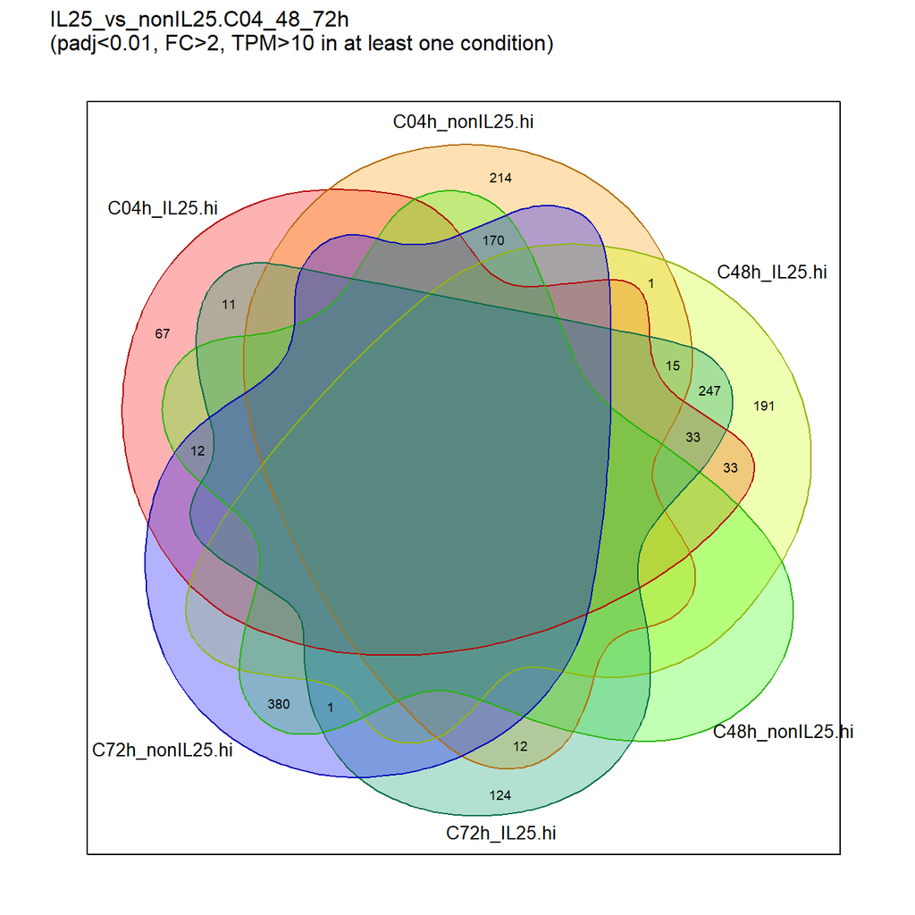

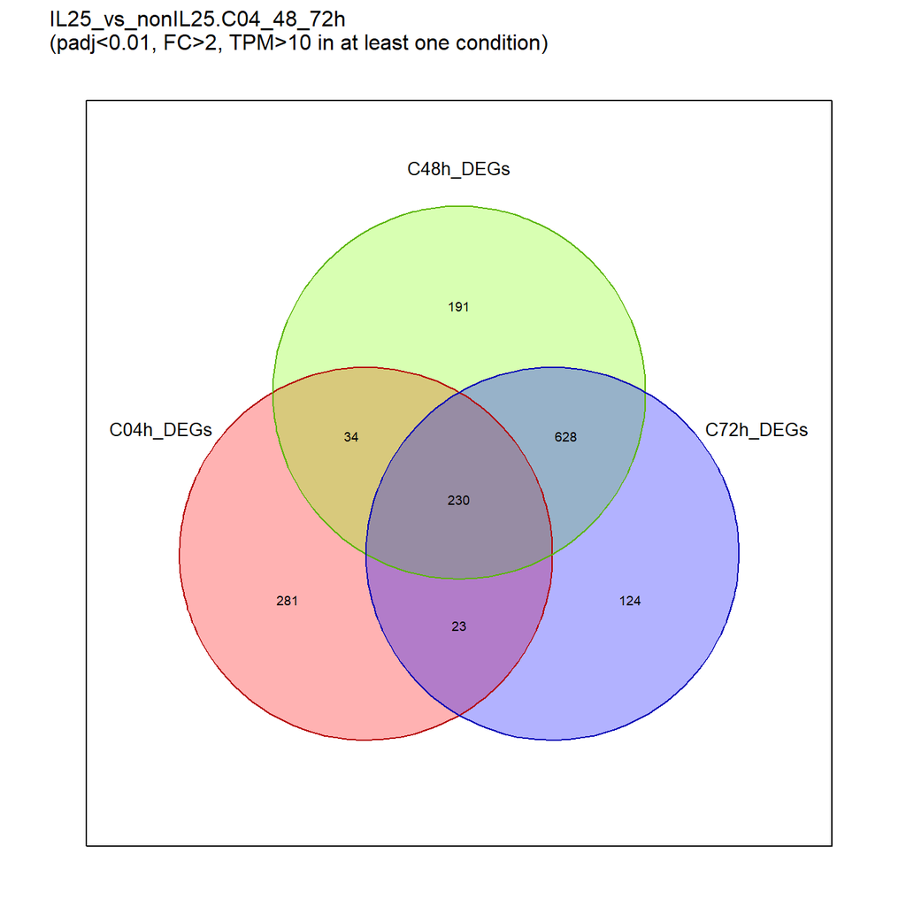

##### IL25

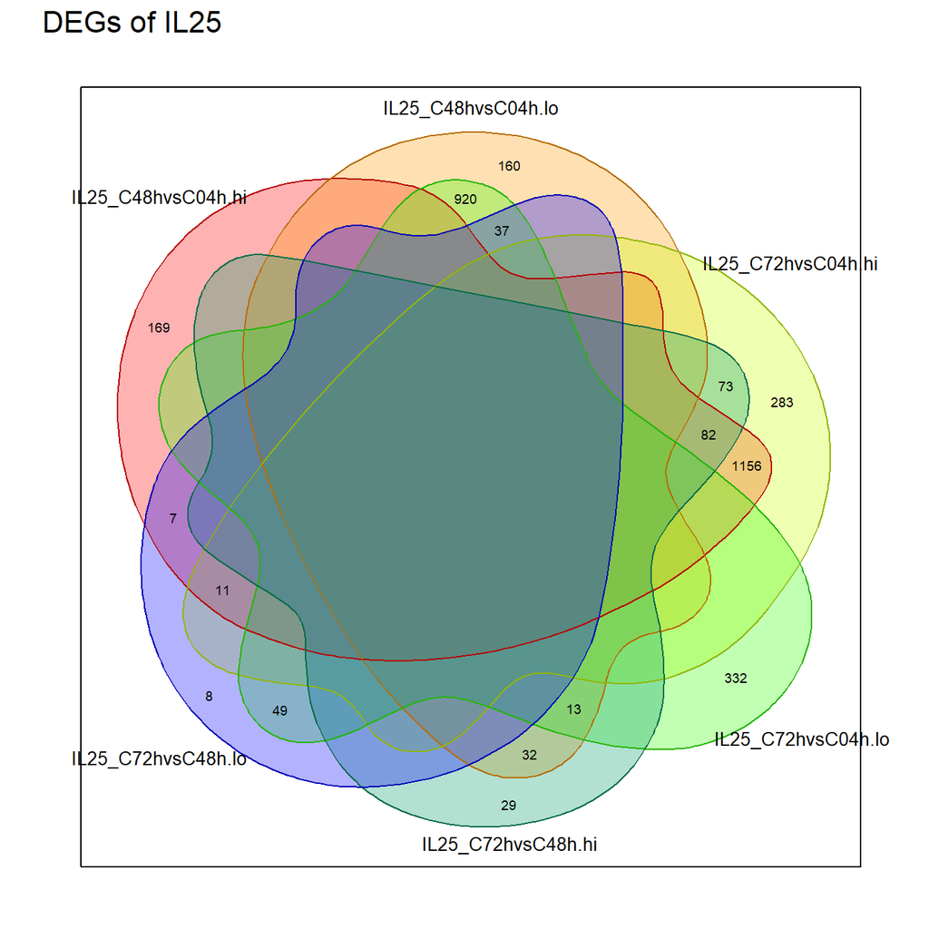

##### nonIL25

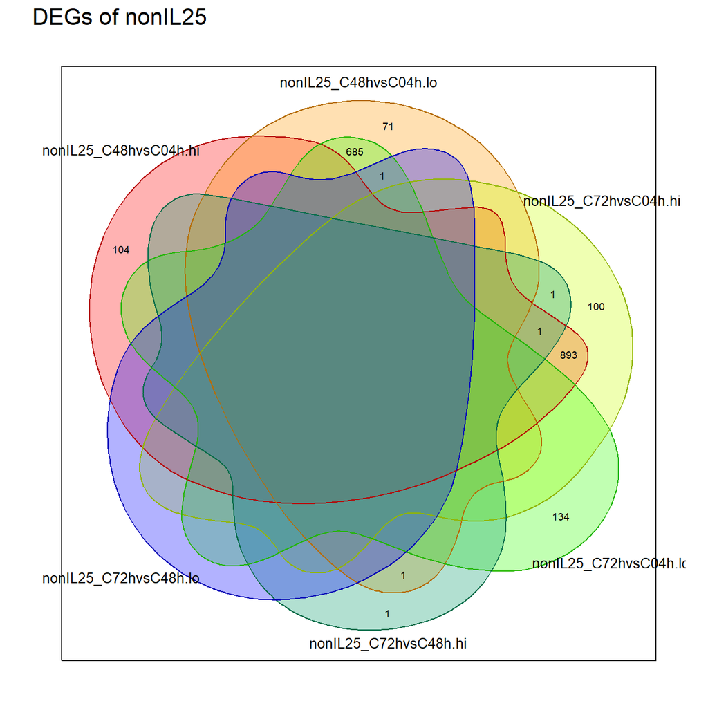

##### C48h vs C04h

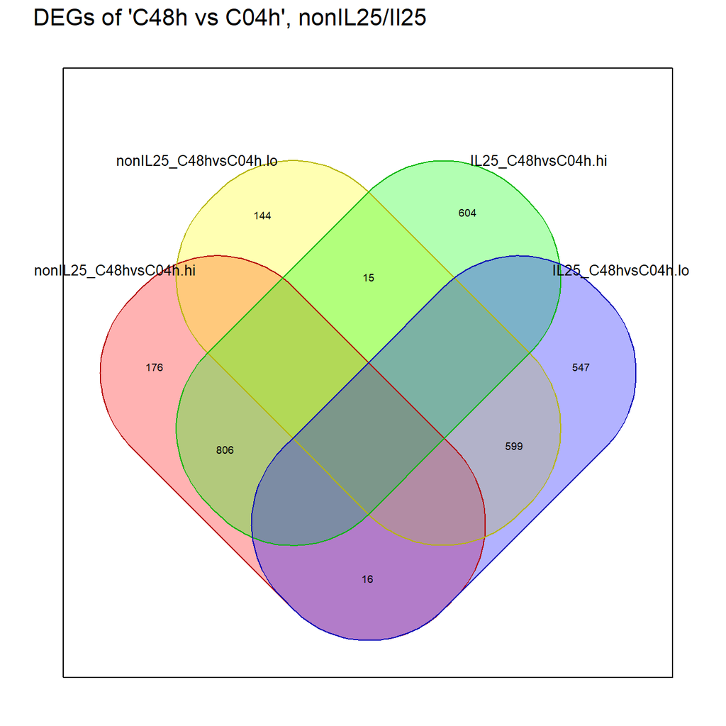

##### C72h vs C04h

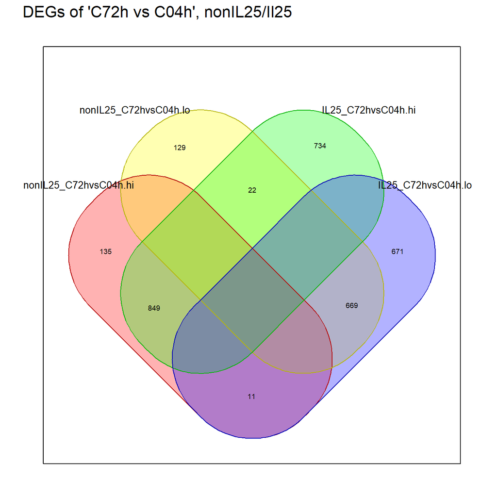

##### C72h vs C48h

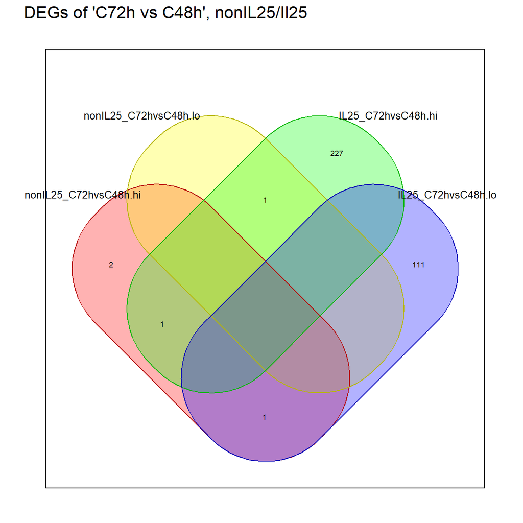

#### merged DEGs

```r
DEGs.nonIL25_m <- unique(c(nonIL25_C48hvsC04h.hi,
                           nonIL25_C48hvsC04h.lo,
                           nonIL25_C72hvsC04h.hi,
                           nonIL25_C72hvsC04h.lo,
                           nonIL25_C72hvsC48h.hi,
                           nonIL25_C72hvsC48h.lo))
DEGs.IL25_m <- unique(c(IL25_C48hvsC04h.hi,
                        IL25_C48hvsC04h.lo,
                        IL25_C72hvsC04h.hi,
                        IL25_C72hvsC04h.lo,
                        IL25_C72hvsC48h.hi,
                        IL25_C72hvsC48h.lo))
DEGs.times_m <- unique(c(C04h_IL25.hi,C04h_nonIL25.hi,
                                   C48h_IL25.hi,C48h_nonIL25.hi,
                                   C72h_IL25.hi,C72h_nonIL25.hi))
```

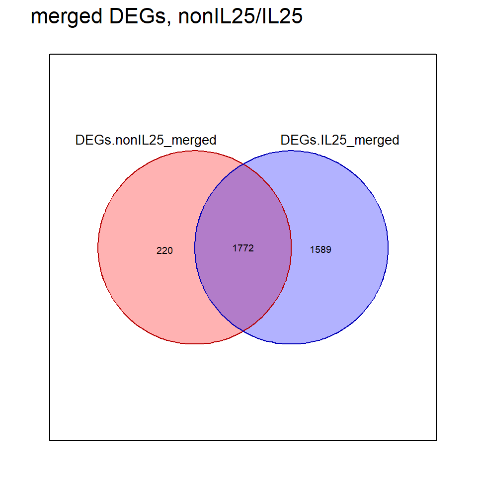

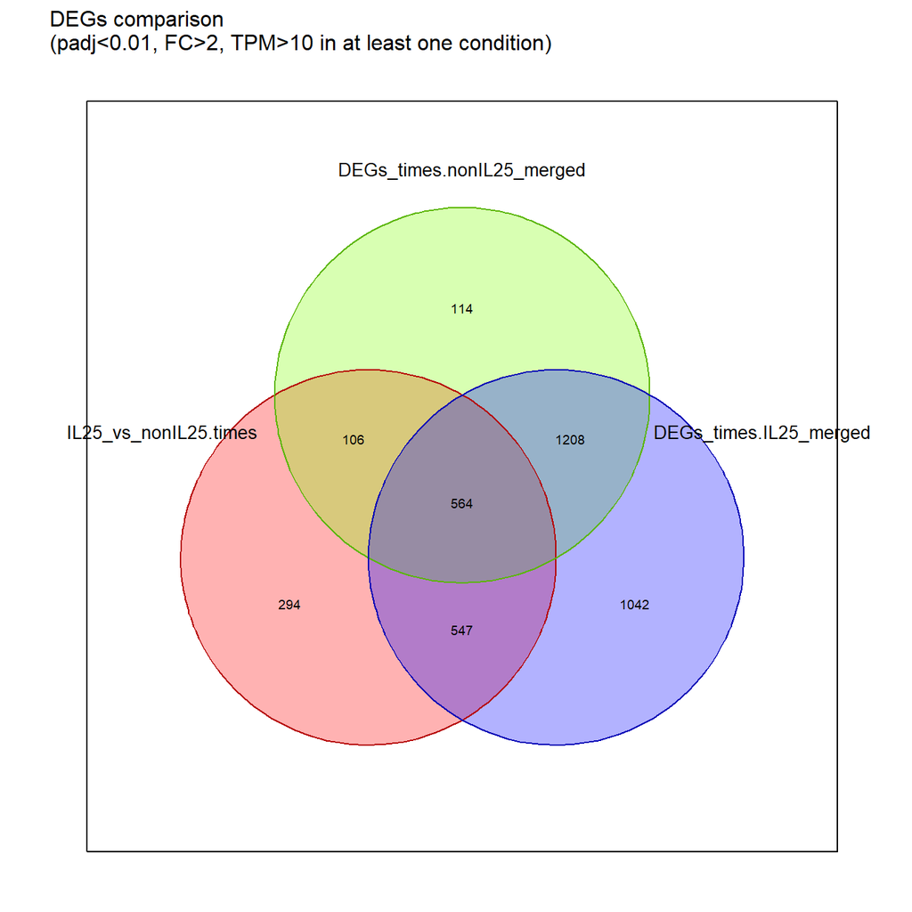

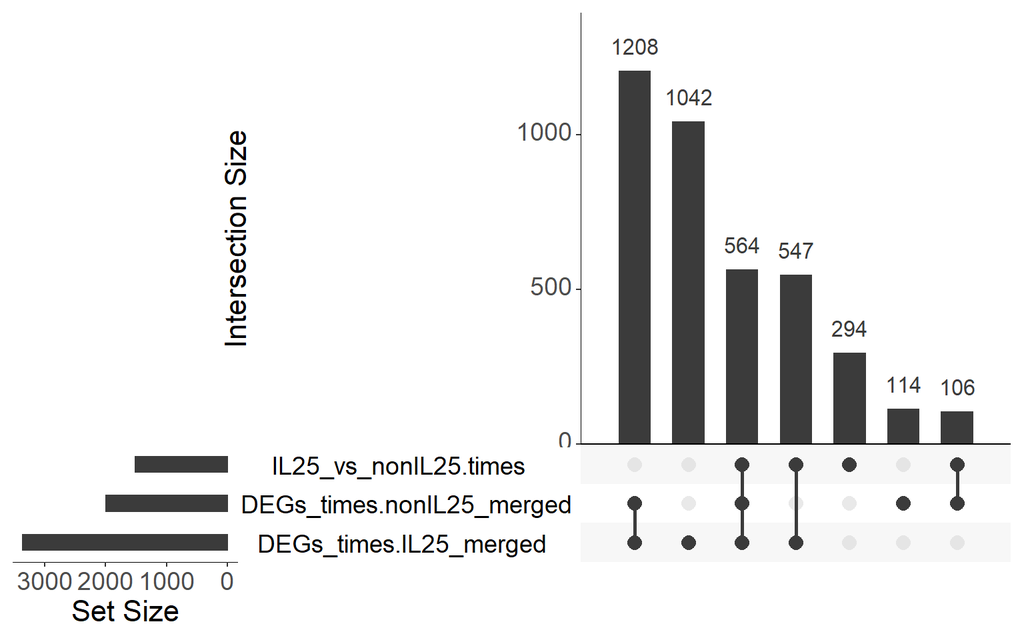

filtering method:

to find specific patterns for IL25+/- across time points, define:  
i. must have difference of ‘IL25 vs nonIL25’ in at least one time point;  
ii. must have different trend across ‘C04h-C48h-C72h’ for IL25/nonIL25.

so we have certain candidate DEGs in  
a. ‘IL25_vs_nonIL25.times’ and ‘DEGs_times.nonIL25_merged’ but not in ‘DEGs_tines.IL25_merged’;  
b. ‘IL25_vs_nonIL25.times’ and ‘DEGs_times.IL25_merged’ but not in ‘DEGs_tines.nonIL25_merged’.

for overlapped DEGs in three-overlap geneset,  
to find DEGs with different trend as candidates.

#### different trend

##### set a vector to check these DEGs

each gene, if in:  
c(C48hvsC04h.hi, C48hvsC04h.lo, C72hvsC04h.hi, C72hvsC04h.lo, C72hvsC48h.hi, C72hvsC48h.lo)  
if the IL25-vector == nonIL25-vector, then this gene is not specific which would be excluded

```r
DEGs.IL25vsnon.vstimes.m <- intersect(intersect(DEGs.times_m, DEGs.nonIL25_m), DEGs.IL25_m)
DEGs.IL25vsnon.vstimes_nonIL25.m <- setdiff(intersect(DEGs.times_m, DEGs.nonIL25_m),DEGs.IL25vsnon.vstimes.m)
DEGs.IL25vsnon.vstimes_IL25.m <- setdiff(intersect(DEGs.times_m, DEGs.IL25_m),DEGs.IL25vsnon.vstimes.m)

DEGs.IL25vsnon.vstimes.all <- c(DEGs.IL25vsnon.vstimes.m,
                                DEGs.IL25vsnon.vstimes_IL25.m,
                                DEGs.IL25vsnon.vstimes_nonIL25.m)
```

```r
DEGs2vector <- function(DEGs,DEG1_1=IL25_C48hvsC04h.hi,
                             DEG1_2=IL25_C48hvsC04h.lo,
                             DEG1_3=IL25_C72hvsC04h.hi,
                             DEG1_4=IL25_C72hvsC04h.lo,
                             DEG1_5=IL25_C72hvsC48h.hi,
                             DEG1_6=IL25_C72hvsC48h.lo,
                             DEG2_1=nonIL25_C48hvsC04h.hi,
                             DEG2_2=nonIL25_C48hvsC04h.lo,
                             DEG2_3=nonIL25_C72hvsC04h.hi,
                             DEG2_4=nonIL25_C72hvsC04h.lo,
                             DEG2_5=nonIL25_C72hvsC48h.hi,
                             DEG2_6=nonIL25_C72hvsC48h.lo){
    v1 <- c(DEGs[1] %in% DEG1_1,
              DEGs[1] %in% DEG1_2,
              DEGs[1] %in% DEG1_3,
              DEGs[1] %in% DEG1_4,
              DEGs[1] %in% DEG1_5,
              DEGs[1] %in% DEG1_6)
    v2 <- c(DEGs[1] %in% DEG2_1,
              DEGs[1] %in% DEG2_2,
              DEGs[1] %in% DEG2_3,
              DEGs[1] %in% DEG2_4,
              DEGs[1] %in% DEG2_5,
              DEGs[1] %in% DEG2_6)
    ret <- list(inIL25=v1,
                innonIL25=v2,
                identical=c(identical(v1,v2)))
    for(i in 2:length(DEGs)){
      v1 <- c(DEGs[i] %in% DEG1_1,
              DEGs[i] %in% DEG1_2,
              DEGs[i] %in% DEG1_3,
              DEGs[i] %in% DEG1_4,
              DEGs[i] %in% DEG1_5,
              DEGs[i] %in% DEG1_6)
      v2 <- c(DEGs[i] %in% DEG2_1,
              DEGs[i] %in% DEG2_2,
              DEGs[i] %in% DEG2_3,
              DEGs[i] %in% DEG2_4,
              DEGs[i] %in% DEG2_5,
              DEGs[i] %in% DEG2_6)
      ret$inIL25 <- rbind(ret$inIL25,v1)
      ret$innonIL25 <- rbind(ret$innonIL25,v2)
      ret$identical <- c(ret$identical,c(identical(v1,v2)))
    }
    ret$specific <- !(ret$identical)
    rownames(ret$inIL25) <- rownames(ret$innonIL25) <- names(ret$identical) <- names(ret$specific) <- DEGs
    return(ret)
}
```

```r
mat_spe.IL25 <- DEGs2vector(DEGs.IL25vsnon.vstimes_IL25.m)
mat_spe.nonIL25 <- DEGs2vector(DEGs.IL25vsnon.vstimes_nonIL25.m)
mat_spe.overlap3 <- DEGs2vector(DEGs.IL25vsnon.vstimes.m)
```

##### check the decision matrix

```r
lapply(mat_spe.IL25,head)
```

```
## $inIL25
##          [,1]  [,2]  [,3]  [,4]  [,5]  [,6]
## Serp1   FALSE  TRUE FALSE FALSE FALSE FALSE
## Nfkbia  FALSE  TRUE FALSE  TRUE FALSE FALSE
## Dennd5a FALSE  TRUE FALSE  TRUE FALSE FALSE
## Il13    FALSE FALSE  TRUE FALSE FALSE FALSE
## Il5     FALSE FALSE  TRUE FALSE FALSE FALSE
## Nfkbiz  FALSE  TRUE FALSE  TRUE FALSE FALSE
##
## $innonIL25
##          [,1]  [,2]  [,3]  [,4]  [,5]  [,6]
## Serp1   FALSE FALSE FALSE FALSE FALSE FALSE
## Nfkbia  FALSE FALSE FALSE FALSE FALSE FALSE
## Dennd5a FALSE FALSE FALSE FALSE FALSE FALSE
## Il13    FALSE FALSE FALSE FALSE FALSE FALSE
## Il5     FALSE FALSE FALSE FALSE FALSE FALSE
## Nfkbiz  FALSE FALSE FALSE FALSE FALSE FALSE
##
## $identical
##   Serp1  Nfkbia Dennd5a    Il13     Il5  Nfkbiz
##   FALSE   FALSE   FALSE   FALSE   FALSE   FALSE
##
## $specific
##   Serp1  Nfkbia Dennd5a    Il13     Il5  Nfkbiz
##    TRUE    TRUE    TRUE    TRUE    TRUE    TRUE
```

```r
lapply(mat_spe.nonIL25,head)
```

```
## $inIL25
##          [,1]  [,2]  [,3]  [,4]  [,5]  [,6]
## Pim2    FALSE FALSE FALSE FALSE FALSE FALSE
## Tph1    FALSE FALSE FALSE FALSE FALSE FALSE
## Gadd45g FALSE FALSE FALSE FALSE FALSE FALSE
## Mras    FALSE FALSE FALSE FALSE FALSE FALSE
## Mthfd2  FALSE FALSE FALSE FALSE FALSE FALSE
## Irak3   FALSE FALSE FALSE FALSE FALSE FALSE
##
## $innonIL25
##          [,1]  [,2]  [,3]  [,4]  [,5]  [,6]
## Pim2    FALSE  TRUE FALSE  TRUE FALSE FALSE
## Tph1    FALSE FALSE  TRUE FALSE FALSE FALSE
## Gadd45g  TRUE FALSE  TRUE FALSE FALSE FALSE
## Mras    FALSE  TRUE FALSE  TRUE FALSE FALSE
## Mthfd2   TRUE FALSE FALSE FALSE FALSE FALSE
## Irak3   FALSE FALSE FALSE  TRUE FALSE FALSE
##
## $identical
##    Pim2    Tph1 Gadd45g    Mras  Mthfd2   Irak3
##   FALSE   FALSE   FALSE   FALSE   FALSE   FALSE
##
## $specific
##    Pim2    Tph1 Gadd45g    Mras  Mthfd2   Irak3
##    TRUE    TRUE    TRUE    TRUE    TRUE    TRUE
```

```r
lapply(mat_spe.overlap3,head)
```

```
## $inIL25
##         [,1] [,2]  [,3] [,4]  [,5]  [,6]
## Ccr4   FALSE TRUE FALSE TRUE FALSE  TRUE
## Dgat2  FALSE TRUE FALSE TRUE FALSE FALSE
## Pecam1 FALSE TRUE FALSE TRUE FALSE FALSE
## Cd72   FALSE TRUE FALSE TRUE FALSE FALSE
## Il9    FALSE TRUE FALSE TRUE FALSE  TRUE
## Hacd3  FALSE TRUE FALSE TRUE FALSE FALSE
##
## $innonIL25
##         [,1]  [,2]  [,3] [,4]  [,5]  [,6]
## Ccr4   FALSE  TRUE FALSE TRUE FALSE FALSE
## Dgat2  FALSE  TRUE FALSE TRUE FALSE FALSE
## Pecam1 FALSE FALSE FALSE TRUE FALSE FALSE
## Cd72   FALSE  TRUE FALSE TRUE FALSE FALSE
## Il9    FALSE  TRUE FALSE TRUE FALSE FALSE
## Hacd3  FALSE  TRUE FALSE TRUE FALSE FALSE
##
## $identical
##   Ccr4  Dgat2 Pecam1   Cd72    Il9  Hacd3
##  FALSE   TRUE  FALSE   TRUE  FALSE   TRUE
##
## $specific
##   Ccr4  Dgat2 Pecam1   Cd72    Il9  Hacd3
##   TRUE  FALSE   TRUE  FALSE   TRUE  FALSE
```

##### stat

```r
#
sum(mat_spe.IL25$identical)
```

```
## [1] 0
```

```r
sum(mat_spe.nonIL25$identical)
```

```
## [1] 0
```

```r
sum(mat_spe.overlap3$identical)
```

```
## [1] 282
```

```r
#
sum(mat_spe.IL25$specific)
```

```
## [1] 547
```

```r
sum(mat_spe.nonIL25$specific)
```

```
## [1] 106
```

```r
sum(mat_spe.overlap3$specific)
```

```
## [1] 282
```

```r
sum(sum(mat_spe.IL25$specific),
    sum(mat_spe.nonIL25$specific),
    sum(mat_spe.overlap3$specific))
```

```
## [1] 935
```

#### candidate DEGs

```r
gene_spe <- function(mat_spe,identical=TRUE){
  if(identical==TRUE){
    genes <- names(mat_spe$identical)[mat_spe$identical]
  }else{
    genes <- names(mat_spe$specific)[mat_spe$specific]
  }
}
```

```r
deg_spe.IL25 <- gene_spe(mat_spe.IL25, identical = F)
deg_spe.nonIL25 <- gene_spe(mat_spe.nonIL25, identical = F)
deg_spe.ol3 <- gene_spe(mat_spe.overlap3, identical = F)
deg_ide.ol3 <- gene_spe(mat_spe.overlap3, identical = T)
```

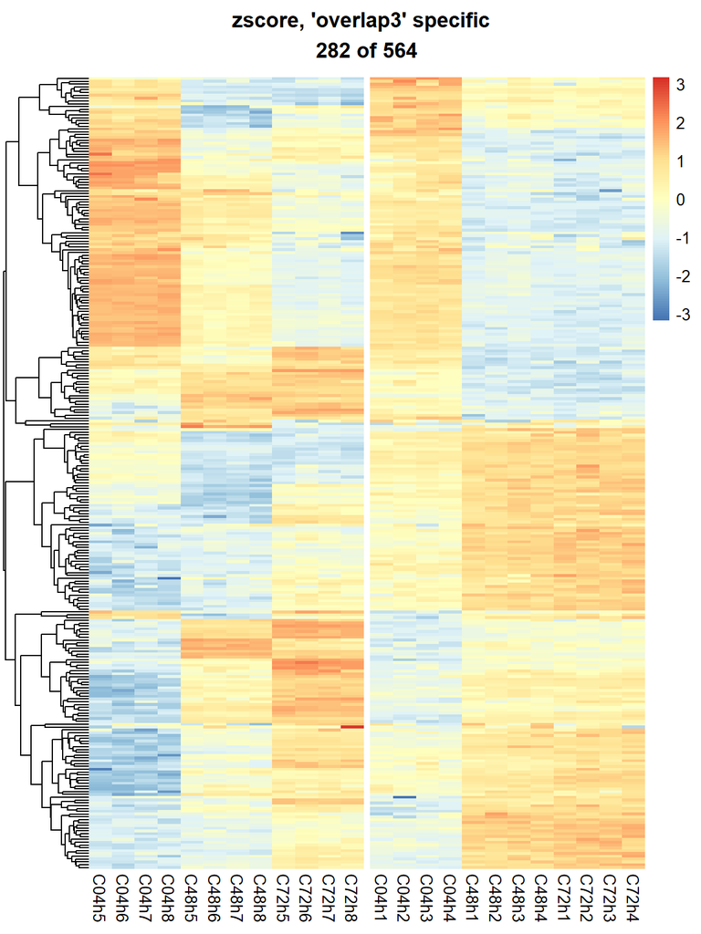

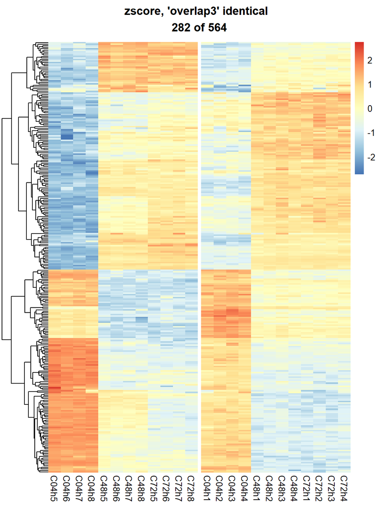

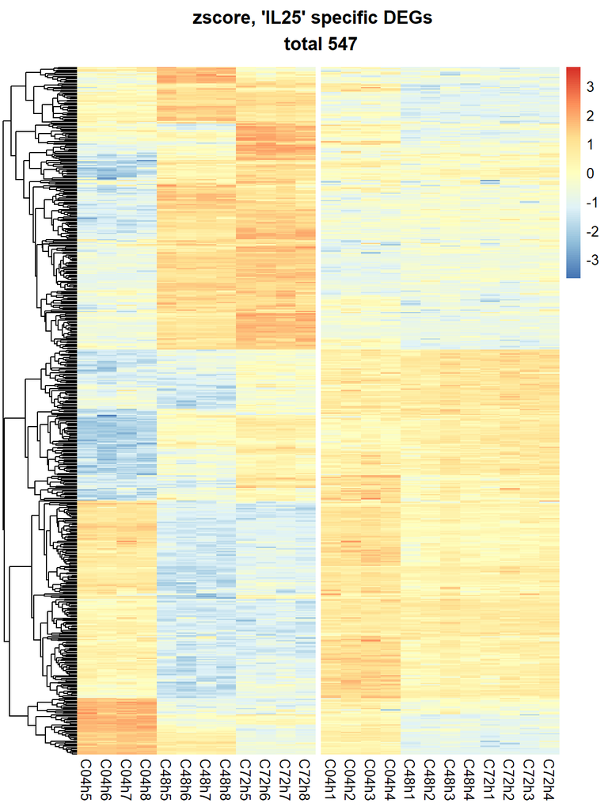

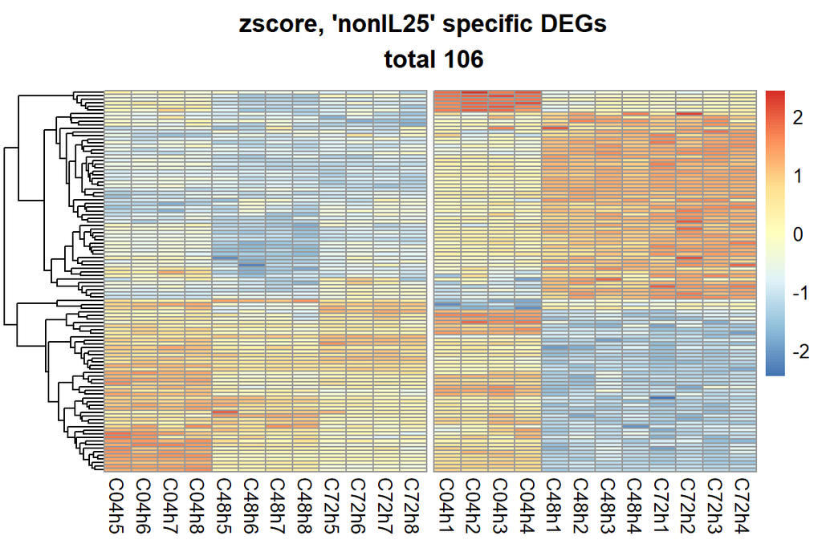

### specific patterns

##### using ‘IL25-specific’ and ‘nonIL25-specific’ and ‘3-overlap with different trend’ DEGs to get different gene expression patterns through hierarchical clustering

how to find the specific patterns ? checked

1. https://github.com/BaselAbujamous/clust
2. http://www.bioconductor.org/packages/release/bioc/html/Mfuzz.html
3. manual way in R, as https://tavareshugo.github.io/data-carpentry-rnaseq/04b_rnaseq_clustering.html

by comparison of their results, determine to choose the final one.

#### count scaled score

##### matrix to cluster patterns

treating nonIL25_C04h as IL25_C00h to 4 time points for IL25 patterns

```r
DEGs.adv2 <- c(deg_spe.IL25,
              deg_spe.nonIL25,
              deg_spe.ol3)

matt_pc.adv2 <- cbind(DEGs.adv2, round(log2(matt_pc.cut[DEGs.adv2,c(idx.nonIL25_C04h,
                                                                    idx.IL25_C04h,
                                                                    idx.IL25_C48h,
                                                                    idx.IL25_C72h)]+1),4))
colnames(matt_pc.adv2)[1] <- "gene"
```

```r
dim(matt_pc.adv2)
```

```
## [1] 935  17
```

```r
head(matt_pc.adv2)
```

```
##            gene  C04h1  C04h2  C04h3  C04h4   C04h5   C04h6   C04h7   C04h8
## Serp1     Serp1 7.7669 7.8068 7.8663 7.7675  8.9924  8.9732  9.0142  9.0278
## Nfkbia   Nfkbia 8.4522 8.3789 8.4713 8.2278 10.0727 10.0371  9.9515 10.0813
## Dennd5a Dennd5a 5.7814 5.8733 5.9146 5.8890  7.2365  7.2491  7.3559  7.4045
## Il13       Il13 4.5154 4.3923 4.6775 4.8227  7.2661  7.2897  7.1583  7.2381
## Il5         Il5 8.3411 8.2736 8.9440 8.3171 11.1183 11.1133 10.8058 10.9008
## Nfkbiz   Nfkbiz 6.1150 6.5245 6.3107 6.0306  7.6267  7.5177  7.9065  7.6734
##           C48h5   C48h6   C48h7   C48h8   C72h5   C72h6   C72h7   C72h8
## Serp1    7.4631  7.3485  7.3994  7.3692  7.7134  7.8119  7.7826  7.7854
## Nfkbia   8.1813  7.8054  7.9915  8.2303  8.1799  7.9702  7.7992  8.0915
## Dennd5a  5.4296  5.3621  5.1243  5.0561  5.8883  6.2182  6.1629  5.8873
## Il13     7.6409  7.7057  7.6650  7.5839  8.6936  8.1932  8.1633  8.4959
## Il5     11.1888 10.9296 10.9850 11.0336 11.7527 11.5267 11.3850 11.8014
## Nfkbiz   5.9923  5.7962  5.7960  5.5376  5.7460  5.8562  6.0358  5.5589
```

##### mean zscore based on this matrix

```r
cnts <- c(rep("C00h_IL25",4),
          rep("C04h_IL25",4),
          rep("C48h_IL25",4),
          rep("C72h_IL25",4))
reps <- c(rep(1:4,4))
sample_info <- data.frame(sample=colnames(matt_pc.adv2[,-1]),
                          condition=cnts,
                          batch=rep(c(rep("IL25",4)),4),
                          time=c(rep("C00h",4),rep("C04h",4),rep("C48h",4),rep("C72h",4)),
                          replicate = reps)
sample_info
```

```
##    sample condition batch time replicate
## 1   C04h1 C00h_IL25  IL25 C00h         1
## 2   C04h2 C00h_IL25  IL25 C00h         2
## 3   C04h3 C00h_IL25  IL25 C00h         3
## 4   C04h4 C00h_IL25  IL25 C00h         4
## 5   C04h5 C04h_IL25  IL25 C04h         1
## 6   C04h6 C04h_IL25  IL25 C04h         2
## 7   C04h7 C04h_IL25  IL25 C04h         3
## 8   C04h8 C04h_IL25  IL25 C04h         4
## 9   C48h5 C48h_IL25  IL25 C48h         1
## 10  C48h6 C48h_IL25  IL25 C48h         2
## 11  C48h7 C48h_IL25  IL25 C48h         3
## 12  C48h8 C48h_IL25  IL25 C48h         4
## 13  C72h5 C72h_IL25  IL25 C72h         1
## 14  C72h6 C72h_IL25  IL25 C72h         2
## 15  C72h7 C72h_IL25  IL25 C72h         3
## 16  C72h8 C72h_IL25  IL25 C72h         4
```

```
## # A tibble: 12 x 5
##    gene          batch time  mean_tpm_scaled  nrep
##    <chr>         <chr> <chr>           <dbl> <int>
##  1 1110059E24Rik IL25  C00h           -0.878     4
##  2 1110059E24Rik IL25  C04h           -1.03      4
##  3 1110059E24Rik IL25  C48h            1.06      4
##  4 1110059E24Rik IL25  C72h            0.844     4
##  5 1500009L16Rik IL25  C00h           -0.926     4
##  6 1500009L16Rik IL25  C04h           -0.980     4
##  7 1500009L16Rik IL25  C48h            0.784     4
##  8 1500009L16Rik IL25  C72h            1.12      4
##  9 2700097O09Rik IL25  C00h           -1.16      4
## 10 2700097O09Rik IL25  C04h           -0.713     4
## 11 2700097O09Rik IL25  C48h            0.983     4
## 12 2700097O09Rik IL25  C72h            0.890     4
```

#### hclust

```r
gene_dist.adv2 <- dist(zscore_mat(matt_pc.adv2[,-1]))
```

##### range to select a suitable ‘Height’ to get well separated patterns

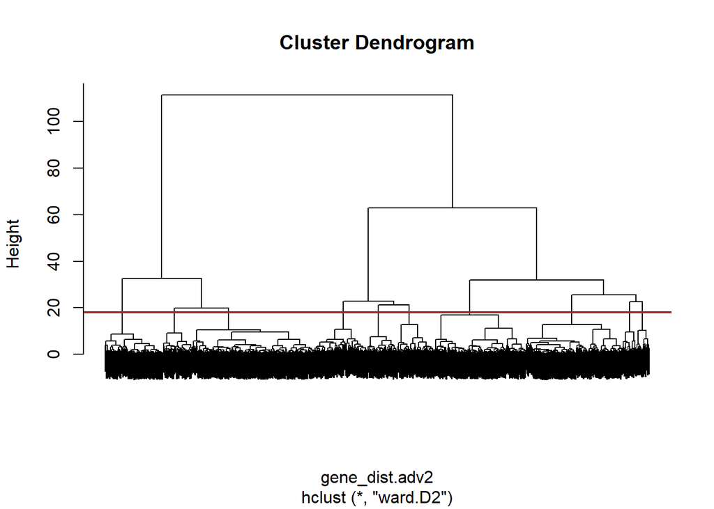

```r
h.adv2 <- 18
gene_hclust.adv2 <- hclust(gene_dist.adv2,method = 'ward.D2')

plot(gene_hclust.adv2, labels = FALSE)
abline(h = h.adv2, col = "brown", lwd = 2)
```

```r
show_clust(cutree(gene_hclust.adv2,h=h.adv2))
```

```
## clust_ret
##  cluster1  cluster2  cluster3  cluster4  cluster5  cluster6  cluster7  cluster8
##        51        24       166       100        22       209        92        51
##  cluster9 cluster10
##        63       157
```

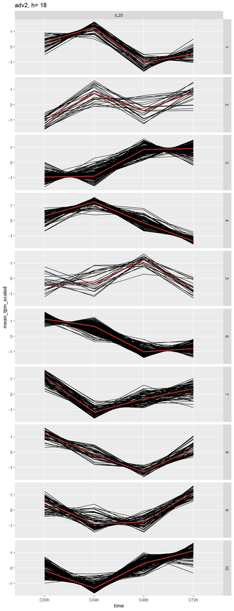

#### manually sorted patterns

##### each pattern, give it to the time point which has the biggest median score;

##### for genes in each pattern of each time point, sort by score decreasingly.

```r
trans_tpm_cluster.adv2.median <- trans_tpm_cluster.adv2 %>%
  group_by(cluster,time) %>%
  summarize(median_score=median(mean_tpm_scaled)) %>%
  reshape2::dcast(cluster~time)

reorder_scalemat <- function(scale_mat){
  scale_mat1 <- scale_mat[scale_mat[,2]==rowMaxs(as.matrix(scale_mat[,2:5])),] %>%
    arrange(desc(colnames(scale_mat)[2]))
  scale_mat2 <- scale_mat[scale_mat[,3]==rowMaxs(as.matrix(scale_mat[,2:5])),] %>%
    arrange(desc(colnames(scale_mat)[3]))
  scale_mat3 <- scale_mat[scale_mat[,4]==rowMaxs(as.matrix(scale_mat[,2:5])),] %>%
    arrange(desc(colnames(scale_mat)[4]))
  scale_mat4 <- scale_mat[scale_mat[,5]==rowMaxs(as.matrix(scale_mat[,2:5])),] %>%
    arrange(desc(colnames(scale_mat)[5]))
  reorder_list <- list(C00h=scale_mat1$cluster,
                C04h=scale_mat2$cluster,
                C48h=scale_mat3$cluster,
                C72h=scale_mat4$cluster)
  return(reorder_list)
}
reorder_cluster <- reorder_scalemat(scale_mat = trans_tpm_cluster.adv2.median)

trans_tpm_cluster.adv2.median[unlist(reorder_cluster) ,]
```

```
##    cluster       C00h       C04h       C48h       C72h
## 6        6  1.1378849  0.6664357 -1.0119355 -0.8004011
## 7        7  1.1479916 -1.1715959 -0.2985601  0.3713393
## 8        8  1.2284665 -0.1528769 -1.2936969  0.2352935
## 1        1  0.2975066  1.2792730 -1.0503623 -0.4504435
## 4        4  0.2947320  1.2189839 -0.1566568 -1.3505832
## 5        5 -0.3623943 -0.2994309  1.2278312 -0.7637991
## 2        2 -1.0063446  0.7275123 -0.3959249  0.8439284
## 3        3 -0.9460980 -0.8904184  0.8586174  0.9167619
## 9        9  0.5449935 -0.9242311 -0.7798738  1.1655003
## 10      10 -0.1690978 -1.3297366  0.2998973  1.1241619
```

```r
reorder_cluster
```

```
## $C00h
## [1] 6 7 8
##
## $C04h
## [1] 1 4
##
## $C48h
## [1] 5
##
## $C72h
## [1]  2  3  9 10
```

```r
head(trans_tpm_cluster.adv2)
```

```
## # A tibble: 6 x 6
##   gene          batch time  mean_tpm_scaled  nrep cluster
##   <chr>         <chr> <chr>           <dbl> <int>   <int>
## 1 1110059E24Rik IL25  C00h           -0.878     4       3
## 2 1110059E24Rik IL25  C04h           -1.03      4       3
## 3 1110059E24Rik IL25  C48h            1.06      4       3
## 4 1110059E24Rik IL25  C72h            0.844     4       3
## 5 1500009L16Rik IL25  C00h           -0.926     4       3
## 6 1500009L16Rik IL25  C04h           -0.980     4       3
```

```r
names(reorder_cluster )
```

```
## [1] "C00h" "C04h" "C48h" "C72h"
```

```r
# reorder_gene
reorder_gene <- list(C00h=list(),
                     C04h=list(),
                     C48h=list(),
                     C72h=list())
for(i in 1:4){
  for(j in 1:length(reorder_cluster[[i]])){
    if(j==1){
      reorder_gene[[i]] <- list((trans_tpm_cluster.adv2 %>% filter(time==names(reorder_cluster)[i],
                                  cluster==reorder_cluster[[i]][j]) %>%
                                  arrange(desc(mean_tpm_scaled)))$gene)
    }else{
      reorder_gene[[i]] <- c(reorder_gene[[i]],list((trans_tpm_cluster.adv2 %>% filter(time==names(reorder_cluster)[i],
                                  cluster==reorder_cluster[[i]][j]) %>%
                                  arrange(desc(mean_tpm_scaled)))$gene))
    }

  }
}

lapply(reorder_gene,function(x) lapply(x,head))
```

```
## $C00h
## $C00h[[1]]
## [1] "Tspan32" "Sfxn3"   "Nt5e"    "St8sia4" "Enpp5"   "F2r"
##
## $C00h[[2]]
## [1] "Ccr9"     "Tnfrsf26" "Hba-a1"   "Lrrc52"   "Dhcr7"    "Rbm43"
##
## $C00h[[3]]
## [1] "Neb"     "Trim34a" "Ifi209"  "Fgl2"    "Tsc22d3" "Tor3a"
##
##
## $C04h
## $C04h[[1]]
## [1] "Nfkbia" "Pecam1" "Serp1"  "Nfkbiz" "Galnt1" "Nfkbib"
##
## $C04h[[2]]
## [1] "Il2ra"   "Fgfr1op" "Plagl2"  "Eef1e1"  "Mfsd2a"  "Tmem97"
##
##
## $C48h
## $C48h[[1]]
## [1] "Serpine2" "Dusp22"   "Psrc1"    "Gpx1"     "Fam3c"    "Def8"
##
##
## $C72h
## $C72h[[1]]
## [1] "Adam8"    "Smox"     "Cd69"     "Ier3"     "Adora2b"  "Eif4ebp1"
##
## $C72h[[2]]
## [1] "Aldoc" "Pgk1"  "Ero1l" "Alox8" "Bnip3" "Nrros"
##
## $C72h[[3]]
## [1] "Ly6a"     "Tnfrsf18" "Hilpda"   "Htr1b"    "Tnfrsf9"  "Id2"
##
## $C72h[[4]]
## [1] "Prdx5"  "P4ha1"  "Pigz"   "Pgm1"   "Slc2a3" "Ly6g5b"
```

```r
#unlist(reorder_gene)
```

```r
trans_tpm_cluster.adv2.reorder <- trans_tpm_cluster.adv2

trans_tpm_cluster.adv2.reorder$cluster <- factor(trans_tpm_cluster.adv2.reorder$cluster,
                                                 levels = unlist(reorder_cluster))
```

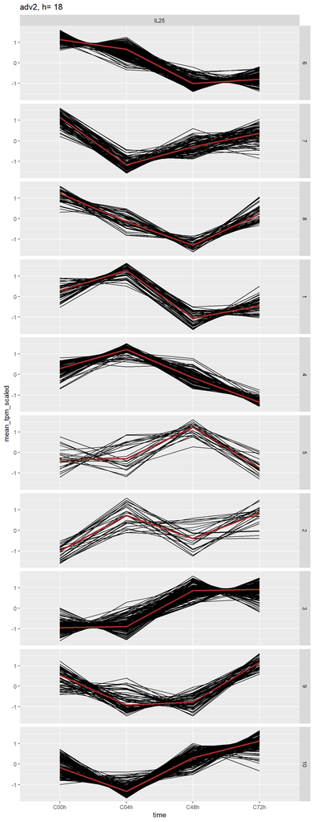

```r
show_clust(cutree(gene_hclust.adv2,h=h.adv2))[paste0("cluster",unlist(reorder_cluster))]
```

```
## clust_ret
##  cluster6  cluster7  cluster8  cluster1  cluster4  cluster5  cluster2  cluster3
##       209        92        51        51       100        22        24       166
##  cluster9 cluster10
##        63       157
```

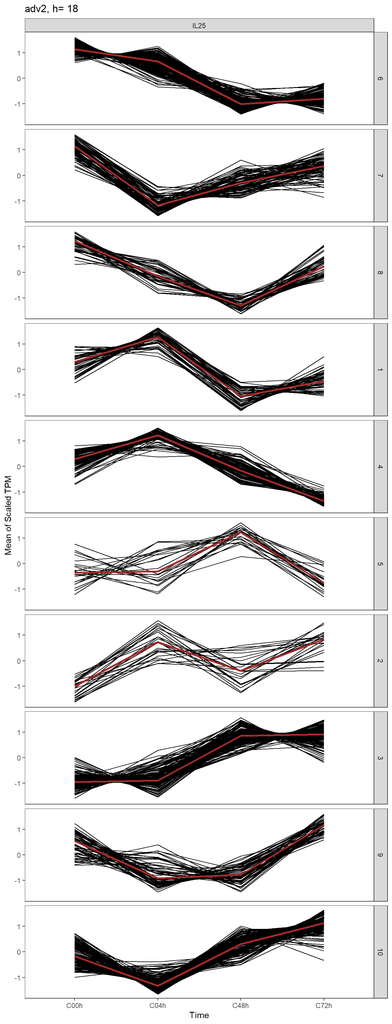

##### 202205mod

```r
#trans_tpm_cluster.adv2.reorder
trans_tpm_cluster.adv2.202205mod <- trans_tpm_cluster.adv2.reorder
trans_tpm_cluster.adv2.202205mod$cluster <- factor(as.character(trans_tpm_cluster.adv2.202205mod$cluster),
                                                   levels = c(6,1,4,3,10,7,9,8,2,5))
```

```r
levels(trans_tpm_cluster.adv2.reorder$cluster)
```

```
##  [1] "6"  "7"  "8"  "1"  "4"  "5"  "2"  "3"  "9"  "10"
```

```r
levels(trans_tpm_cluster.adv2.202205mod$cluster)
```

```
##  [1] "6"  "1"  "4"  "3"  "10" "7"  "9"  "8"  "2"  "5"
```

```r
head(trans_tpm_cluster.adv2.202205mod,10)
```

```
## # A tibble: 10 x 6
##    gene          batch time  mean_tpm_scaled  nrep cluster
##    <chr>         <chr> <chr>           <dbl> <int> <fct>
##  1 1110059E24Rik IL25  C00h           -0.878     4 3
##  2 1110059E24Rik IL25  C04h           -1.03      4 3
##  3 1110059E24Rik IL25  C48h            1.06      4 3
##  4 1110059E24Rik IL25  C72h            0.844     4 3
##  5 1500009L16Rik IL25  C00h           -0.926     4 3
##  6 1500009L16Rik IL25  C04h           -0.980     4 3
##  7 1500009L16Rik IL25  C48h            0.784     4 3
##  8 1500009L16Rik IL25  C72h            1.12      4 3
##  9 2700097O09Rik IL25  C00h           -1.16      4 3
## 10 2700097O09Rik IL25  C04h           -0.713     4 3
```

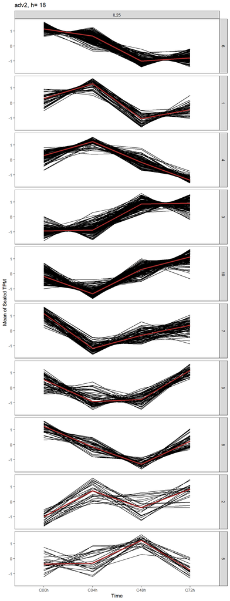

```r
head(genes.plot.adv2)
```

```
## # A tibble: 6 x 2
##   gene    cluster
##   <chr>     <int>
## 1 Tspan32       6
## 2 Sfxn3         6
## 3 Nt5e          6
## 4 St8sia4       6
## 5 Enpp5         6
## 6 F2r           6
```

[output not shown]

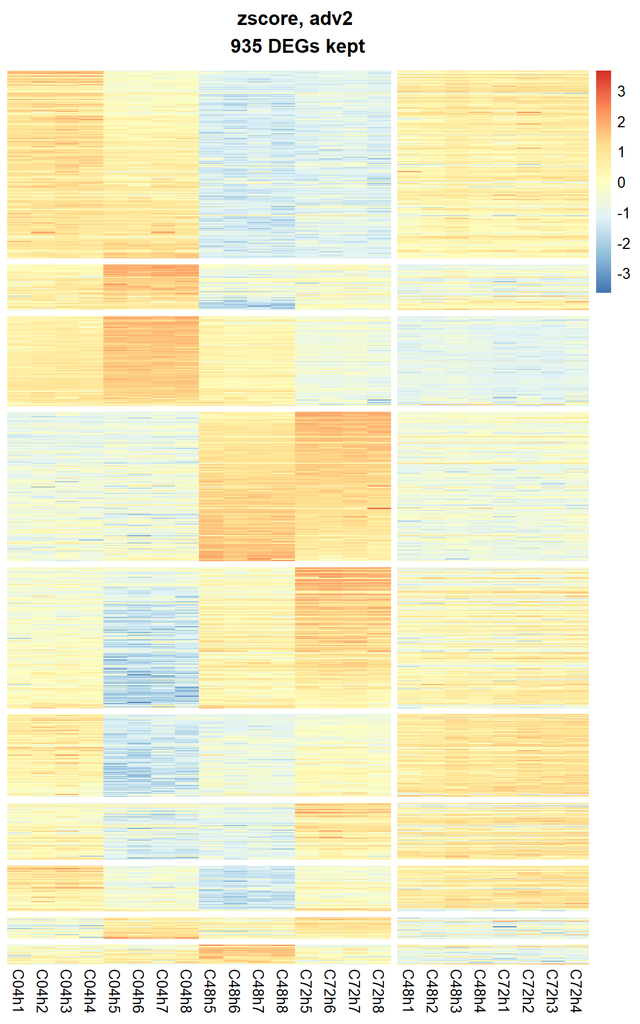

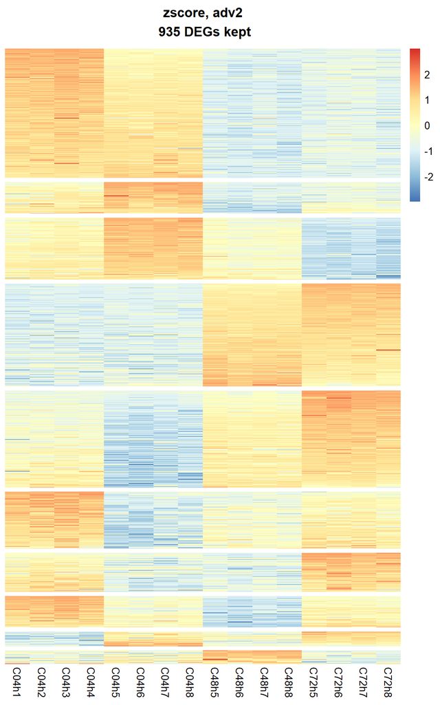

```r
## 2022mod for genes.plot.adv2
genes.plot.adv2.202205mod <- rbind(genes.plot.adv2 %>% filter(cluster == 6),
                                   genes.plot.adv2 %>% filter(cluster == 1),
                                   genes.plot.adv2 %>% filter(cluster == 4),
                                   genes.plot.adv2 %>% filter(cluster == 3),
                                   genes.plot.adv2 %>% filter(cluster == 10),
                                   genes.plot.adv2 %>% filter(cluster == 7),
                                   genes.plot.adv2 %>% filter(cluster == 9),
                                   genes.plot.adv2 %>% filter(cluster == 8),
                                   genes.plot.adv2 %>% filter(cluster == 2),
                                   genes.plot.adv2 %>% filter(cluster == 5))
unique(genes.plot.adv2.202205mod$cluster)
```

[output not shown]

```r
head(trans_tpm_cluster.adv2.202205mod)
```

```
## # A tibble: 6 x 6
##   gene          batch time  mean_tpm_scaled  nrep cluster
##   <chr>         <chr> <chr>           <dbl> <int> <fct>
## 1 1110059E24Rik IL25  C00h           -0.878     4 3
## 2 1110059E24Rik IL25  C04h           -1.03      4 3
## 3 1110059E24Rik IL25  C48h            1.06      4 3
## 4 1110059E24Rik IL25  C72h            0.844     4 3
## 5 1500009L16Rik IL25  C00h           -0.926     4 3
## 6 1500009L16Rik IL25  C04h           -0.980     4 3
```

```r
median.pattern.adv2_4.mod202205 <- trans_tpm_cluster.adv2.202205mod %>%
  select(cluster, time, mean_tpm_scaled) %>%
  group_by(cluster, time) %>%
  summarize(median = median(mean_tpm_scaled)) %>%
  reshape2::dcast(cluster~time)
colnames(median.pattern.adv2_4.mod202205) <- c("cluster.manually_sorted","C00h.median","C04h.median","C48h.median","C72h.median")

median.pattern.adv2_4.mod202205
```

```
##    cluster.manually_sorted C00h.median C04h.median C48h.median C72h.median
## 1                        6   1.1378849   0.6664357  -1.0119355  -0.8004011
## 2                        1   0.2975066   1.2792730  -1.0503623  -0.4504435
## 3                        4   0.2947320   1.2189839  -0.1566568  -1.3505832
## 4                        3  -0.9460980  -0.8904184   0.8586174   0.9167619
## 5                       10  -0.1690978  -1.3297366   0.2998973   1.1241619
## 6                        7   1.1479916  -1.1715959  -0.2985601   0.3713393
## 7                        9   0.5449935  -0.9242311  -0.7798738   1.1655003
## 8                        8   1.2284665  -0.1528769  -1.2936969   0.2352935
## 9                        2  -1.0063446   0.7275123  -0.3959249   0.8439284
## 10                       5  -0.3623943  -0.2994309   1.2278312  -0.7637991
```

#### each pattern run go/kegg enrichment

```r
reorder_cluster
```

```
## $C00h
## [1] 6 7 8
##
## $C04h
## [1] 1 4
##
## $C48h
## [1] 5
##
## $C72h
## [1]  2  3  9 10
```

(run in linux shell with modified script)

#### split by DEG source

##### from C04h DEGs

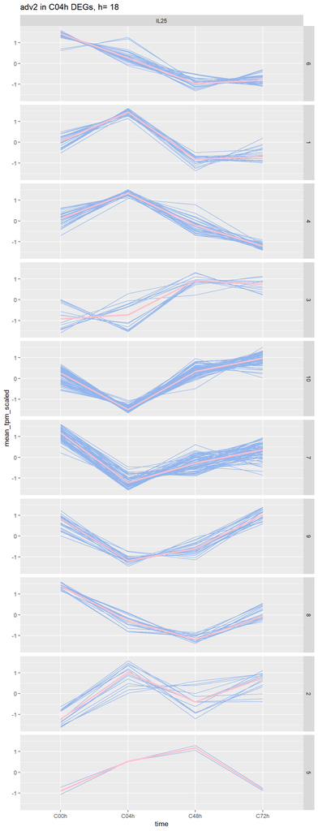

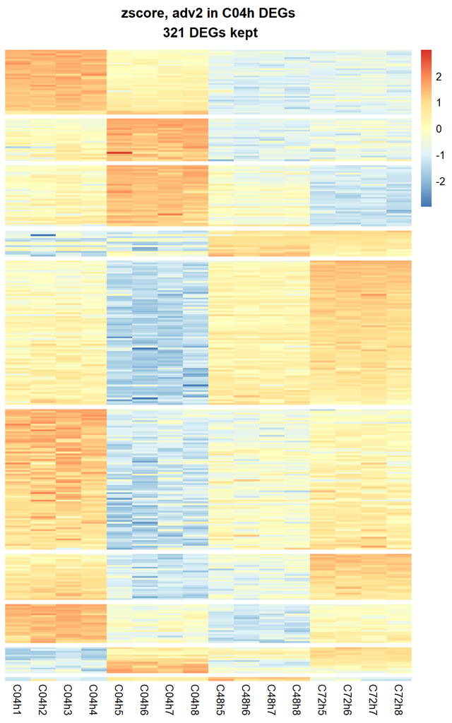

##### from C48h DEGs

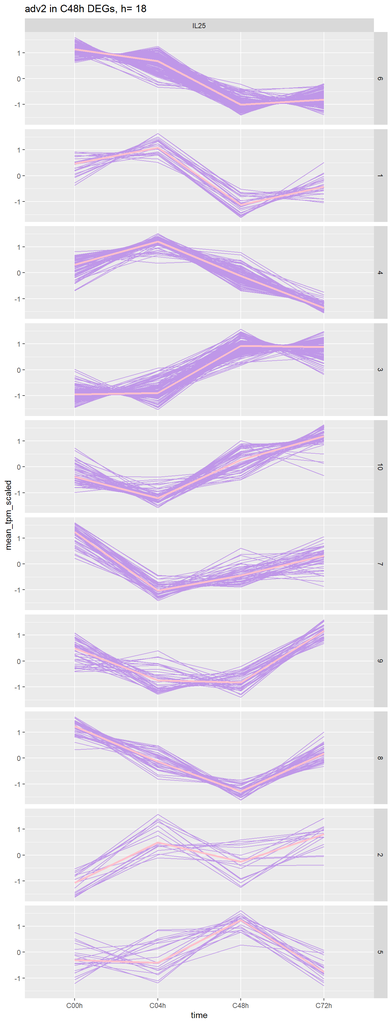

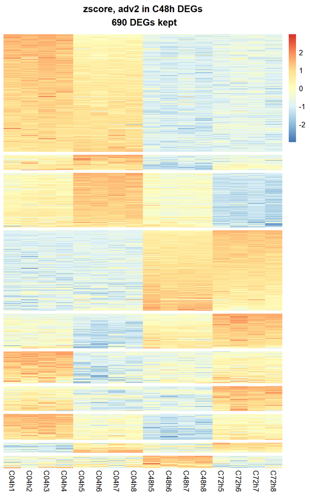

##### from C72h DEGs

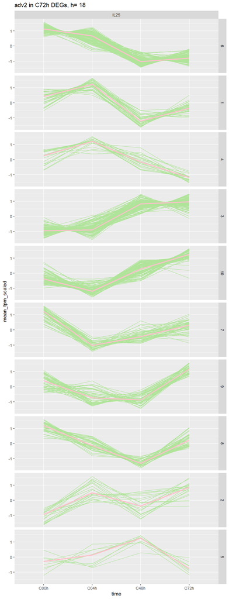

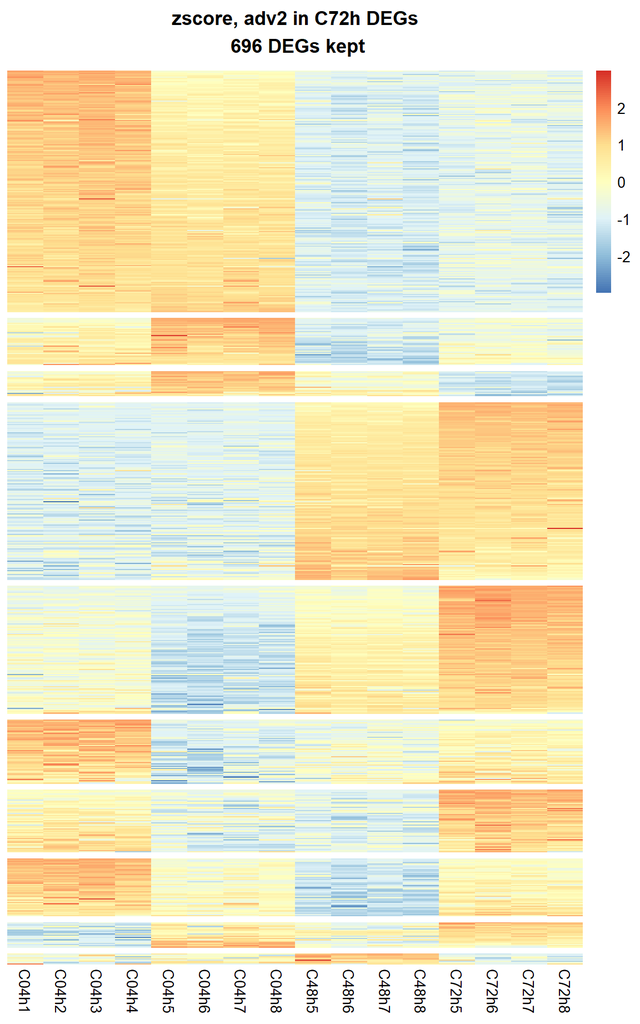

### overlap with GO:0003700

#### overlap of DEGs

```r
go.0003700 <- read.table("../GO0003700.txt",header = TRUE, sep = "\t")
```

```r
length(go.0003700$Gene.name)
```

```
## [1] 1361
```

```r
head(go.0003700$Gene.name)
```

```
## [1] "Zfy1"   "Zfy2"   "Sry"    "Vsx2"   "Nr1i2"  "Tfap2a"
```

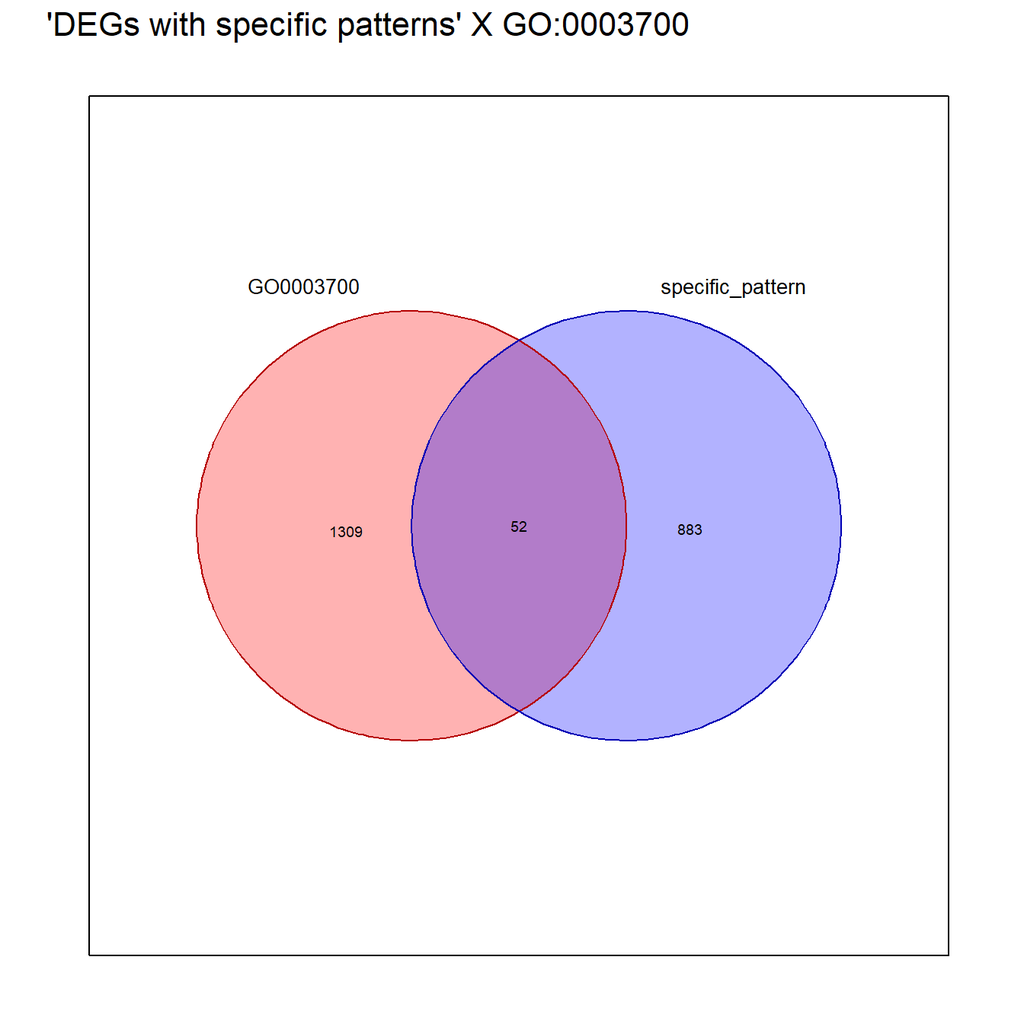

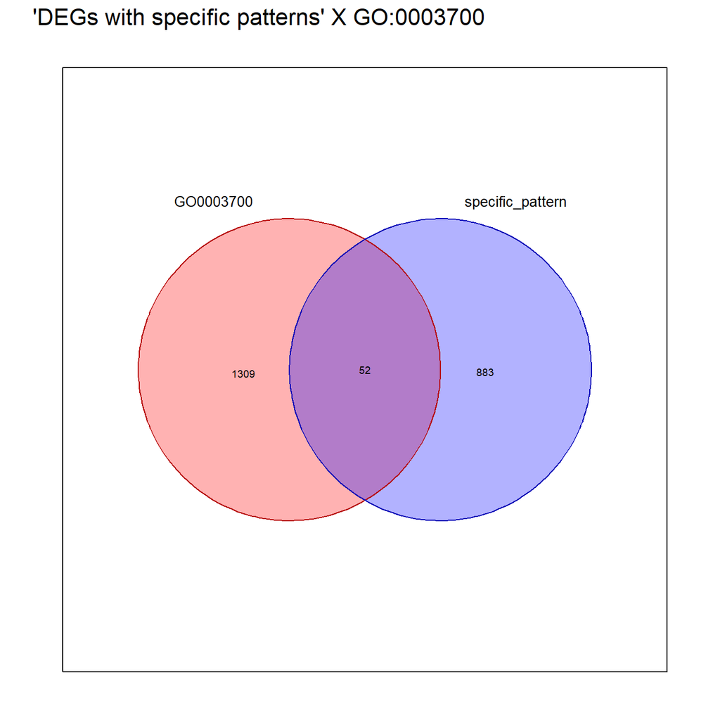

```r
library(grid)
```